# Hitters in R

Michael Roberto

2025-09-14

```r
getwd()
```

```
## [1] "/Users/michaelroberto/Desktop"
```

```r
#load ISLR for dataset and readr/ggplots from Tidyverse
library(ISLR)
library(readr)
library(ggplot2)
```

```r
head(Hitters)
```

```
##                   AtBat Hits HmRun Runs RBI Walks Years CAtBat CHits CHmRun
## -Andy Allanson      293   66     1   30  29    14     1    293    66      1
## -Alan Ashby         315   81     7   24  38    39    14   3449   835     69
## -Alvin Davis        479  130    18   66  72    76     3   1624   457     63
## -Andre Dawson       496  141    20   65  78    37    11   5628  1575    225
## -Andres Galarraga   321   87    10   39  42    30     2    396   101     12
## -Alfredo Griffin    594  169     4   74  51    35    11   4408  1133     19
##                   CRuns CRBI CWalks League Division PutOuts Assists Errors
## -Andy Allanson       30   29     14      A        E     446      33     20
## -Alan Ashby         321  414    375      N        W     632      43     10
## -Alvin Davis        224  266    263      A        W     880      82     14
## -Andre Dawson       828  838    354      N        E     200      11      3
## -Andres Galarraga    48   46     33      N        E     805      40      4
## -Alfredo Griffin    501  336    194      A        W     282     421     25
##                   Salary NewLeague
## -Andy Allanson        NA         A
## -Alan Ashby        475.0         N
## -Alvin Davis       480.0         A
## -Andre Dawson      500.0         N
## -Andres Galarraga   91.5         N
## -Alfredo Griffin   750.0         A
```

```r
tail(Hitters)
```

```
##                   AtBat Hits HmRun Runs RBI Walks Years CAtBat CHits CHmRun
## -Wayne Krenchicki   221   53     2   21  23    22     8   1063   283     15
## -Willie McGee       497  127     7   65  48    37     5   2703   806     32
## -Willie Randolph    492  136     5   76  50    94    12   5511  1511     39
## -Wayne Tolleson     475  126     3   61  43    52     6   1700   433      7
## -Willie Upshaw      573  144     9   85  60    78     8   3198   857     97
## -Willie Wilson      631  170     9   77  44    31    11   4908  1457     30
##                   CRuns CRBI CWalks League Division PutOuts Assists Errors
## -Wayne Krenchicki   107  124    106      N        E     325      58      6
## -Willie McGee       379  311    138      N        E     325       9      3
## -Willie Randolph    897  451    875      A        E     313     381     20
## -Wayne Tolleson     217   93    146      A        W      37     113      7
## -Willie Upshaw      470  420    332      A        E    1314     131     12
## -Willie Wilson      775  357    249      A        W     408       4      3
##                   Salary NewLeague
## -Wayne Krenchicki     NA         N
## -Willie McGee        700         N
## -Willie Randolph     875         A
## -Wayne Tolleson      385         A
## -Willie Upshaw       960         A
## -Willie Wilson      1000         A
```

```r
summary(Hitters)
```

```
##      AtBat            Hits         HmRun            Runs
##  Min.   : 16.0   Min.   :  1   Min.   : 0.00   Min.   :  0.00
##  1st Qu.:255.2   1st Qu.: 64   1st Qu.: 4.00   1st Qu.: 30.25
##  Median :379.5   Median : 96   Median : 8.00   Median : 48.00
##  Mean   :380.9   Mean   :101   Mean   :10.77   Mean   : 50.91
##  3rd Qu.:512.0   3rd Qu.:137   3rd Qu.:16.00   3rd Qu.: 69.00
##  Max.   :687.0   Max.   :238   Max.   :40.00   Max.   :130.00
##
##       RBI             Walks            Years            CAtBat
##  Min.   :  0.00   Min.   :  0.00   Min.   : 1.000   Min.   :   19.0
##  1st Qu.: 28.00   1st Qu.: 22.00   1st Qu.: 4.000   1st Qu.:  816.8
##  Median : 44.00   Median : 35.00   Median : 6.000   Median : 1928.0
##  Mean   : 48.03   Mean   : 38.74   Mean   : 7.444   Mean   : 2648.7
##  3rd Qu.: 64.75   3rd Qu.: 53.00   3rd Qu.:11.000   3rd Qu.: 3924.2
##  Max.   :121.00   Max.   :105.00   Max.   :24.000   Max.   :14053.0
##
##      CHits            CHmRun           CRuns             CRBI
##  Min.   :   4.0   Min.   :  0.00   Min.   :   1.0   Min.   :   0.00
##  1st Qu.: 209.0   1st Qu.: 14.00   1st Qu.: 100.2   1st Qu.:  88.75
##  Median : 508.0   Median : 37.50   Median : 247.0   Median : 220.50
##  Mean   : 717.6   Mean   : 69.49   Mean   : 358.8   Mean   : 330.12
##  3rd Qu.:1059.2   3rd Qu.: 90.00   3rd Qu.: 526.2   3rd Qu.: 426.25
##  Max.   :4256.0   Max.   :548.00   Max.   :2165.0   Max.   :1659.00
##
##      CWalks        League  Division    PutOuts          Assists
##  Min.   :   0.00   A:175   E:157    Min.   :   0.0   Min.   :  0.0
##  1st Qu.:  67.25   N:147   W:165    1st Qu.: 109.2   1st Qu.:  7.0
##  Median : 170.50                    Median : 212.0   Median : 39.5
##  Mean   : 260.24                    Mean   : 288.9   Mean   :106.9
##  3rd Qu.: 339.25                    3rd Qu.: 325.0   3rd Qu.:166.0
##  Max.   :1566.00                    Max.   :1378.0   Max.   :492.0
##
##      Errors          Salary       NewLeague
##  Min.   : 0.00   Min.   :  67.5   A:176
##  1st Qu.: 3.00   1st Qu.: 190.0   N:146
##  Median : 6.00   Median : 425.0
##  Mean   : 8.04   Mean   : 535.9
##  3rd Qu.:11.00   3rd Qu.: 750.0
##  Max.   :32.00   Max.   :2460.0
##                  NA's   :59
```

```r
dim(Hitters)
```

```
## [1] 322  20
```

#Used functions like head, tail, dim and summary on “Hitters” databse from ISLR #To find mean home runs (HmRun) of hitters

```r
mean(Hitters$HmRun)
```

```
## [1] 10.77019
```

#To find median years (years) of hitters

```r
median(Hitters$Years)
```

```
## [1] 6
```

#The mean homeruns shows the average of homeruns per hitter regardless of years whereas the median years shows the number of years played in the middle of the dataset

```r
fetch_modes <-function(Hitters){
uniq_hitters <- unique(Hitters)
freq_values <-tabulate(match(Hitters,uniq_hitters))
modes_years <- uniq_hitters[freq_values == max(freq_values)]
return(modes_years)
}
mode_hits <- fetch_modes(Hitters$Hits)
mode_hits
```

```
## [1] 53 70 76
```

```r
mode_salary <- fetch_modes(Hitters$Salary)
mode_salary
```

```
## [1] NA
```

```r
mode_division <- fetch_modes(Hitters$Division)
mode_division
```

```
## [1] W
## Levels: E W
```

```r
head(Hitters)
```

```
##                   AtBat Hits HmRun Runs RBI Walks Years CAtBat CHits CHmRun
## -Andy Allanson      293   66     1   30  29    14     1    293    66      1
## -Alan Ashby         315   81     7   24  38    39    14   3449   835     69
## -Alvin Davis        479  130    18   66  72    76     3   1624   457     63
## -Andre Dawson       496  141    20   65  78    37    11   5628  1575    225
## -Andres Galarraga   321   87    10   39  42    30     2    396   101     12
## -Alfredo Griffin    594  169     4   74  51    35    11   4408  1133     19
##                   CRuns CRBI CWalks League Division PutOuts Assists Errors
## -Andy Allanson       30   29     14      A        E     446      33     20
## -Alan Ashby         321  414    375      N        W     632      43     10
## -Alvin Davis        224  266    263      A        W     880      82     14
## -Andre Dawson       828  838    354      N        E     200      11      3
## -Andres Galarraga    48   46     33      N        E     805      40      4
## -Alfredo Griffin    501  336    194      A        W     282     421     25
##                   Salary NewLeague
## -Andy Allanson        NA         A
## -Alan Ashby        475.0         N
## -Alvin Davis       480.0         A
## -Andre Dawson      500.0         N
## -Andres Galarraga   91.5         N
## -Alfredo Griffin   750.0         A
```

#transformation of numerical variable

```r
Hitters$Hits <- log(Hitters$Hits)
head(Hitters)
```

```
##                   AtBat     Hits HmRun Runs RBI Walks Years CAtBat CHits CHmRun
## -Andy Allanson      293 4.189655     1   30  29    14     1    293    66      1
## -Alan Ashby         315 4.394449     7   24  38    39    14   3449   835     69
## -Alvin Davis        479 4.867534    18   66  72    76     3   1624   457     63
## -Andre Dawson       496 4.948760    20   65  78    37    11   5628  1575    225
## -Andres Galarraga   321 4.465908    10   39  42    30     2    396   101     12
## -Alfredo Griffin    594 5.129899     4   74  51    35    11   4408  1133     19
##                   CRuns CRBI CWalks League Division PutOuts Assists Errors
## -Andy Allanson       30   29     14      A        E     446      33     20
## -Alan Ashby         321  414    375      N        W     632      43     10
## -Alvin Davis        224  266    263      A        W     880      82     14
## -Andre Dawson       828  838    354      N        E     200      11      3
## -Andres Galarraga    48   46     33      N        E     805      40      4
## -Alfredo Griffin    501  336    194      A        W     282     421     25
##                   Salary NewLeague
## -Andy Allanson        NA         A
## -Alan Ashby        475.0         N
## -Alvin Davis       480.0         A
## -Andre Dawson      500.0         N
## -Andres Galarraga   91.5         N
## -Alfredo Griffin   750.0         A
```

#plot histogram of home runs (hmrun)

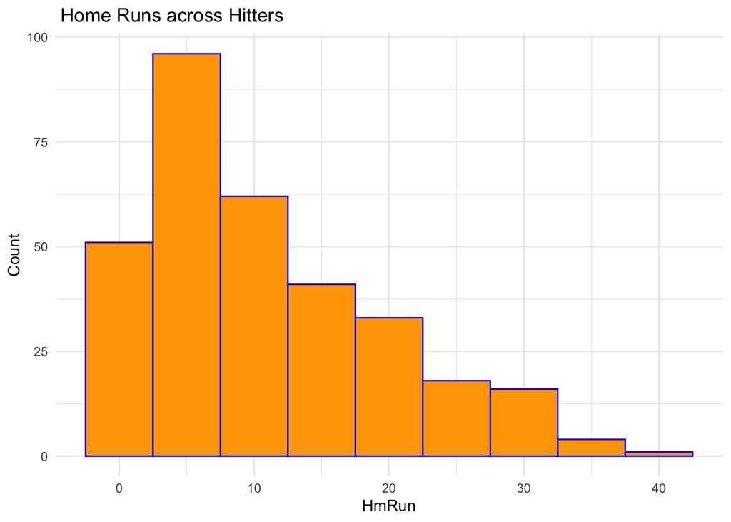

```r
ggplot(Hitters, aes(x = HmRun)) +
geom_histogram(binwidth = 5, fill = "orange", color = "blue") +
labs(title = " Home Runs across Hitters", x = "HmRun", y = "Count") +
theme_minimal()
```

#Histogram interpretation: more hitters (slightly less than 100 total) hit 5 home runs than any number #scatterplot of years to home runs. As the home runs count increases, the volume of players reaching the higher home run number decreases

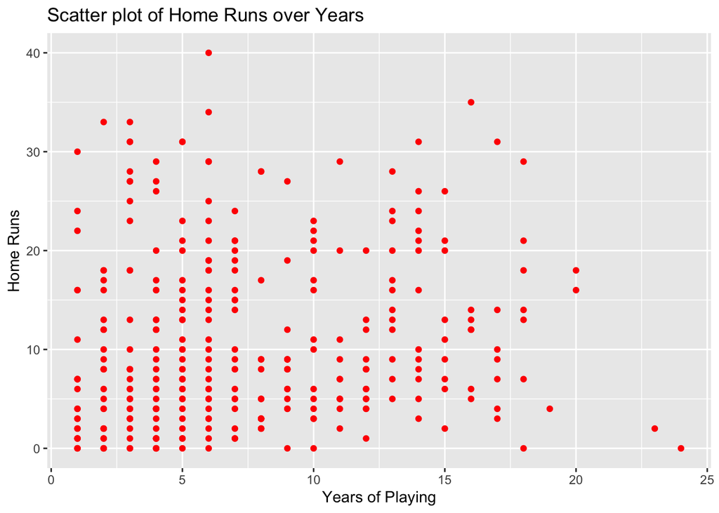

```r
ggplot(Hitters, aes(x = Years, y = HmRun)) +
geom_point(size = 1.5, color = "red") +
labs( title = "Scatter plot of Home Runs over Years", x = "Years of Playing", y = "Home Runs")
```